# StarterSADMAD — FIH Program Simulation & ADPPK Generation

DRAFT

Author

PumasAI

Published

02-May-2026

# 1 Disclaimer

This is a **synthetic** dataset generated by simulation. It is intended for training and demonstration only. Although the structural model and parameters were calibrated to reproduce the published per-cohort summaries from **Nassr et al. 2025** (*Clin. Pharmacol. Ther.* 118:164–176), the individual subject records are computer-generated and must not be used for any regulatory, safety, or efficacy decisions.

# 2 Executive summary

This report performs **Phase 1** of the StarterSADMAD curriculum:

1. Defines a 2-compartment, first-order absorption Pumas model with dose-saturable presystemic bioavailability — chosen to recreate the publication’s supra-proportional Cmax/AUC at low doses, which attenuates for doses ≥ 180 mg.
2. Builds the FIH program population — 76 verum subjects (no placebos) spanning the SAD (6 cohorts, 5–600 mg), Food-effect (200 mg crossover), and MAD (4 cohorts, 100 mg QD; 100/200/300 mg BID × 14 d) arms.
3. Simulates the population with a deterministic seed, exports a CDISC ADaM-style `adppk.csv`, and verifies it round-trips through `read_pumas`.
4. Runs Pumas NCA on the simulated dataset and compares per-cohort geometric means against the publication.

The downstream phases (EDA, NCA training, dose proportionality, food effect, base PK, covariate analysis, model qualification, forest plots) all consume the `adppk.csv` produced here.

# 3 Introduction

The reference publication is summarized in `knowledge-base/sources/cpt-118-164.md` and its supplementary material in `knowledge-base/sources/cpt-118-164-s001.md`. Read those before continuing — every parameter choice in this notebook traces back to a number in those tables.

Coding-style ground rules used throughout (also encoded as project memory):

- `DataFramesMeta` first; raw `DataFrames` only for joins and grouped mutates DFM cannot express cleanly.
- `AlgebraOfGraphics` first; raw `CairoMakie` only for layouts AoG can’t compose.
- Pumas built-ins (`Subject`, `DosageRegimen`, `simobs`, `read_pumas`, `NCA.read_nca`, `NCA.run_nca`) preferred over hand-rolled helpers.
- Heavy “learn-annotate” comments throughout — the script doubles as a tutorial.

# 4 Init

**Initialize required directories**

**Show/Hide Code**

```julia
# Resolve the project root via base-Julia walk-up to Project.toml.
proj_dir = let d = @__DIR__
    while !isfile(joinpath(d, "Project.toml"))
        d = dirname(d)
    end
    d
end

pumasai_repo      = basename(realpath(proj_dir))
utils_dir         = joinpath(proj_dir, "utils")
ddata_dir         = joinpath(proj_dir, "datasets", "derived")
qmd_relative_path = lstrip(split(@__FILE__, pumasai_repo)[end], '/')

include(joinpath(utils_dir, "julia-functions", "init-functions.jl"))
qmd_results_dir = set_results_folder(@__FILE__; clear_existing = true)

mdl_dir       = joinpath(@__DIR__, "pumas")
julia_fns_dir = joinpath(@__DIR__, "julia-functions")
```

**Load packages**

**Show/Hide Code**

```julia
using Pumas
using DataFrames, DataFramesMeta
using AlgebraOfGraphics, CairoMakie
CairoMakie.activate!(px_per_unit = 300/96, type = "png")
using StableRNGs, Random
using Statistics
using LinearAlgebra: Diagonal
using CSV
```

**Load bespoke functions**

**Show/Hide Code**

```julia
include(joinpath(mdl_dir,        "true-model.jl"))
include(joinpath(mdl_dir,        "params.jl"))
include(joinpath(julia_fns_dir,  "build-population.jl"))
include(joinpath(julia_fns_dir,  "adppk-export.jl"))
include(joinpath(julia_fns_dir,  "qc-vs-publication.jl"))
```

# 5 Study design

The cohort table:

**Show/Hide Code**

```julia
DataFrame(
    component = ["SAD",                "FE",                  "MAD-1",         "MAD-2",          "MAD-3",          "MAD-4"],
    cohorts   = ["5,20,60,180,400,600 mg single fasted", "200 mg fasted→fed crossover (14-d washout)",
                 "100 mg QD fasted × 14 d", "100 mg BID fed × 14 d", "200 mg BID fed × 14 d", "300 mg BID fed × 14 d"],
    n         = [36, 8, 8, 8, 8, 8],
)
```

6×3 DataFrame

| Row | component String | cohorts String | n Int64 |
| --- | --- | --- | --- |
| 1 | SAD | 5,20,60,180,400,600 mg single fasted | 36 |
| 2 | FE | 200 mg fasted→fed crossover (14-d washout) | 8 |
| 3 | MAD-1 | 100 mg QD fasted × 14 d | 8 |
| 4 | MAD-2 | 100 mg BID fed × 14 d | 8 |
| 5 | MAD-3 | 200 mg BID fed × 14 d | 8 |
| 6 | MAD-4 | 300 mg BID fed × 14 d | 8 |

# 6 True PK model

A 2-cmt first-order absorption model with **saturable F = Fmax · D / (KF50 + D)**. The full source (heavily annotated) lives at `pumas/true-model.jl`.

Saturation curve sanity-check:

**Show/Hide Code**

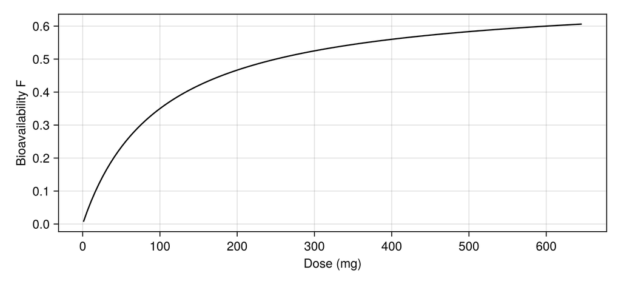

```julia
let
    f(d) = TRUE_PARAMS.tvfmax * d / (TRUE_PARAMS.tvkf50 + d)
    df = DataFrame(dose = 1:5:650, F = f.(1:5:650))
    plt = data(df) * mapping(:dose, :F) * visual(Lines)
    draw(plt; figure = (; size = (700, 320)),
              axis   = (; xlabel = "Dose (mg)", ylabel = "Bioavailability F"))
end
```

# 7 Build population

**Show/Hide Code**

```julia
const STARTERSADMAD_SEED = 20260427
pop = build_population(STARTERSADMAD_SEED)
length(pop), unique([s.covariates(0).STUDY for s in pop])
```

```
(76, ["SAD", "FE", "MAD"])
```

# 8 Simulate

**Show/Hide Code**

```julia
sims = simobs(true_model, pop, TRUE_PARAMS;
              rng = StableRNG(STARTERSADMAD_SEED))
length(sims)
```

```
76
```

# 9 Export ADPPK

**Show/Hide Code**

```julia
adppk = sims_to_adppk(sims)
csv_path = joinpath(ddata_dir, "adppk.csv")
mkpath(dirname(csv_path))
CSV.write(csv_path, adppk; missingstring = ".")
size(adppk), csv_path
```

```
((2366, 37), "/Users/vijay/Repos/pumasAI/StarterSADMAD/datasets/derived/adppk.csv")
```

## 9.1 Round-trip check via `read_pumas`

**Show/Hide Code**

```julia
pop_rt = read_pumas(adppk;
    id           = :USUBJID,
    time         = :NFRLT,
    amt          = :AMT,
    evid         = :EVID,
    cmt          = :CMT,
    observations = [:DV],
    covariates   = [:WTBL, :AGE, :SEX, :FED, :DOSEA],
)
@assert length(pop_rt) == 76
length(pop_rt)
```

```
76
```

# 10 QC vs publication

**Show/Hide Code**

```julia
qc = run_qc(adppk, qmd_results_dir);
nothing
```

[output not shown]

[output cut: 49 more lines]

[output not shown]

## 10.1 Comparison table

**Show/Hide Code**

```julia
@chain qc.comparison begin
    @select :study :cohort :period :parameter :published_geomean :simulated_geomean :pct_diff :within_tol_geomean
end
```

28×8 DataFrame

3 rows omitted

| Row | study String | cohort String | period Int64 | parameter String | published_geomean Float64? | simulated_geomean Float64 | pct_diff Float64? | within_tol_geomean Bool |
| --- | --- | --- | --- | --- | --- | --- | --- | --- |
| 1 | SAD | SAD-020 | 1 | cmax | 5.12 | 3.67441 | -28.2342 | false |
| 2 | SAD | SAD-060 | 1 | cmax | 20.5 | 25.4356 | 24.0761 | false |
| 3 | SAD | SAD-180 | 1 | cmax | 117.0 | 121.858 | 4.15185 | true |
| 4 | SAD | SAD-400 | 1 | cmax | 261.0 | 345.835 | 32.5037 | false |
| 5 | SAD | SAD-600 | 1 | cmax | 483.0 | 642.223 | 32.9655 | false |
| 6 | SAD | SAD-020 | 1 | auclast | 62.8 | 21.5338 | -65.7105 | false |
| 7 | SAD | SAD-060 | 1 | auclast | 335.0 | 276.532 | -17.4531 | true |
| 8 | SAD | SAD-180 | 1 | auclast | 2170.0 | 1725.43 | -20.4871 | false |
| 9 | SAD | SAD-400 | 1 | auclast | 4050.0 | 6765.12 | 67.0399 | false |
| 10 | SAD | SAD-600 | 1 | auclast | 8570.0 | 10964.4 | 27.9398 | false |
| 11 | SAD | SAD-020 | 1 | auc | missing | 103.953 | missing | false |
| 12 | SAD | SAD-060 | 1 | auc | 409.0 | 327.722 | -19.8724 | true |
| 13 | SAD | SAD-180 | 1 | auc | 2330.0 | 1899.12 | -18.4926 | true |
| ⋮ | ⋮ | ⋮ | ⋮ | ⋮ | ⋮ | ⋮ | ⋮ | ⋮ |
| 17 | SAD | SAD-060 | 1 | thalf | 20.9 | 11.6812 | -44.1092 | false |
| 18 | SAD | SAD-180 | 1 | thalf | 27.1 | 26.668 | -1.59417 | true |
| 19 | SAD | SAD-400 | 1 | thalf | 24.0 | 29.1646 | 21.5192 | false |
| 20 | SAD | SAD-600 | 1 | thalf | 23.9 | 23.6157 | -1.18962 | true |
| 21 | FE | FE-200 | 1 | cmax | 119.0 | 144.758 | 21.645 | false |
| 22 | FE | FE-200 | 2 | cmax | 132.0 | 150.894 | 14.3134 | true |
| 23 | FE | FE-200 | 1 | auclast | 1930.0 | 2008.19 | 4.05141 | true |
| 24 | FE | FE-200 | 2 | auclast | 2210.0 | 2258.21 | 2.18153 | true |
| 25 | FE | FE-200 | 1 | auc | 2010.0 | 2150.71 | 7.00031 | true |
| 26 | FE | FE-200 | 2 | auc | 2340.0 | 2365.66 | 1.09672 | true |
| 27 | FE | FE-200 | 1 | thalf | 21.9 | 25.4805 | 16.3494 | true |
| 28 | FE | FE-200 | 2 | thalf | 27.3 | 22.2455 | -18.5147 | true |

**Show/Hide Code**

```julia
println("Geomean within ±20%: ", count(qc.comparison.within_tol_geomean), "/",
        nrow(qc.comparison))
println("CV%   within ±15pp:  ", count(qc.comparison.within_tol_cv), "/",
        nrow(qc.comparison))
```

```
Geomean within ±20%: 13/28
CV%   within ±15pp:  21/28
```

## 10.2 Concentration-time overlay

[figure not shown]

## 10.3 Dose-proportionality plot

[figure not shown]

# 11 Reproducibility

**Show/Hide Code**

```julia
using Pkg
Pkg.status(; mode = Pkg.PKGMODE_PROJECT)
```

```
Status `~/Repos/pumasAI/StarterSADMAD/Project.toml`
⌃ [9917063f] ADaM v0.8.2
⌃ [cbdf2221] AlgebraOfGraphics v0.12.1
⌃ [94b1ba4f] AxisKeys v0.2.16
  [4ece37e6] Bioequivalence v0.4.6
  [daaf709a] BioequivalencePower v0.1.7
  [0a1fb500] BlockDiagonals v0.2.0
⌃ [336ed68f] CSV v0.10.15
⌃ [13f3f980] CairoMakie v0.15.8
⌃ [324d7699] CategoricalArrays v1.0.2
  [8be319e6] Chain v1.0.0
  [35d6a980] ColorSchemes v3.31.0
⌃ [ae264745] Copulas v0.1.32
⌃ [a93c6f00] DataFrames v1.8.1
  [1313f7d8] DataFramesMeta v0.15.6
  [c9661210] DataSets v0.2.13
⌃ [06fc5a27] DynamicQuantities v1.11.0
⌃ [f6369f11] ForwardDiff v1.3.2
⌃ [38e38edf] GLM v1.9.2
⌃ [b6b21f68] Ipopt v1.14.0
⌃ [682c06a0] JSON v1.4.0
  [bc7fa6ce] JuliaHub v0.1.17
  [e241c0f9] JuliaHubData v0.3.10
  [ac0873db] JuliaHubDistributed v0.2.0
⌅ [23fbe1c1] Latexify v0.16.7
⌅ [c7f686f2] MCMCChains v7.5.0
⌃ [ff71e718] MixedModels v5.2.2
⌅ [29142fd5] NCA v2.6.13
⌃ [b07d0016] NCAUtilities v0.15.8
  [d6cf976a] OptimalDesign v0.6.10
  [43a3c2be] PairPlots v3.0.3
  [1ceaab83] PharmaDatasets v0.13.1
  [a03496cd] PlotlyBase v0.8.23
⌃ [8b92943f] PlottingUtilities v0.19.3
  [2f4423a0] ProjectTools v0.1.4
⌃ [4f2c3c20] Pumas v2.8.0
⌃ [897a97e8] PumasAide v1.0.7
⌃ [49473f6d] PumasClusterUtilities v0.1.0
⌃ [0c61e9cd] PumasPlots v0.12.5
  [c743b482] PumasReports v0.9.4
  [148d11e5] PumasUtilities v0.9.3
⌃ [5fded309] QuartoTools v1.1.0
  [52522f7a] ReadStatTables v0.3.5
  [1bc83da4] SafeTestsets v0.1.0
  [860ef19b] StableRNGs v1.0.4
⌃ [90137ffa] StaticArrays v1.9.16
  [2913bbd2] StatsBase v0.34.10
  [6ce4ecf0] SummaryTables v3.5.1
⌃ [8a913413] Survival v0.3.2
  [dc5dba14] TZJData v1.5.0+2025b
  [f269a46b] TimeZones v1.22.2
⌃ [1986cc42] Unitful v1.24.0
⌅ [fdbf4ff8] XLSX v0.10.4
  [44cfe95a] Pkg v1.11.0
  [fa267f1f] TOML v1.0.3
Info Packages marked with ⌃ and ⌅ have new versions available. Those with ⌃ may be upgradable, but those with ⌅ are restricted by compatibility constraints from upgrading. To see why use `status --outdated`
```

**Show/Hide Code**

```julia
@info "Julia $(VERSION) — seed $STARTERSADMAD_SEED"
```

```
[ Info: Julia 1.11.8 — seed 20260427
```